# Condatis connectivity analysis to plan resilient habitat networks - Condatis training in R - Workflow

Jenny Hodgson and Claudia Gutierrez-Arellano

Please note that we are making this code and documentation available under a GPL license; for more details see the LICENSE file. Copyright Jenny Hodgson and Claudia Gutierrez-Arellano 2025 unless otherwise stated (e.g. datasets).

Please cite this archive as: Jenny Hodgson and Claudia Gutierrez-Arellano (2025) Condatis connectivity analysis to plan resilient habitat networks - Condatis training in R. Available at: https://github.com/condatis/Ctraining_inR_25

In this exercise we will perform Condatis analyses in R. As an example, we will assess the connectivity of the wetlands in eastern England. We aim to identify the areas where habitat restoration could have the greatest positive effect for landscape connectivity.

We will obtain the Condatis statistics, the raster layers for the *Flow* and *Progress* metrics, the shapefiles for the *Bottleneck links*, with their associated *power* and *score* metrics. Finally, we will obtain a the shapefile *Search Areas*, based on the score metric.

## How to follow the exercise

You are looking at an R Markdown file, which has chunks of R code interspersed with instructions. You can either copy-paste the R code from your browser into R. Or, you can open the file ‘Workflow.Rmd’ in RStudio and choose ‘run’ next to each code chunk. Only the first chunk (setting the working directory) needs to be adapted to your local machine.

## Data

The data required for this exercise are in the *R example* folder of the [Workshop GitHub repository](https://github.com/condatis/Ctraining_inR_25/tree/main).

Set your working directory using the path where you downloaded the **ZIP**.

```r
setwd("MY PATH/R Example")
```

### Condatis functions and R packages

First, lets source the required functions and libraries for the analyses.

The functions are in the R script stored in the ‘functions’ folder.

```r
source("functions/bottlenecks_functions.R")
```

We need the following R packages to run the Condatis function

```r
library(sf)
library(terra)
library(sfheaders)
library(dplyr)
library(viridis)
```

### Habitat data

First, we need to load the habitat raster, defined in our code as `eghab`. Then, we extract the spatial properties of the raster, i.e. the Coordinate Reference System (crs) and the extent. Condatis requires a raster with units in meters. If your raster is in a different linear unit or in angular units, you will have to project your raster to a crs in meters.

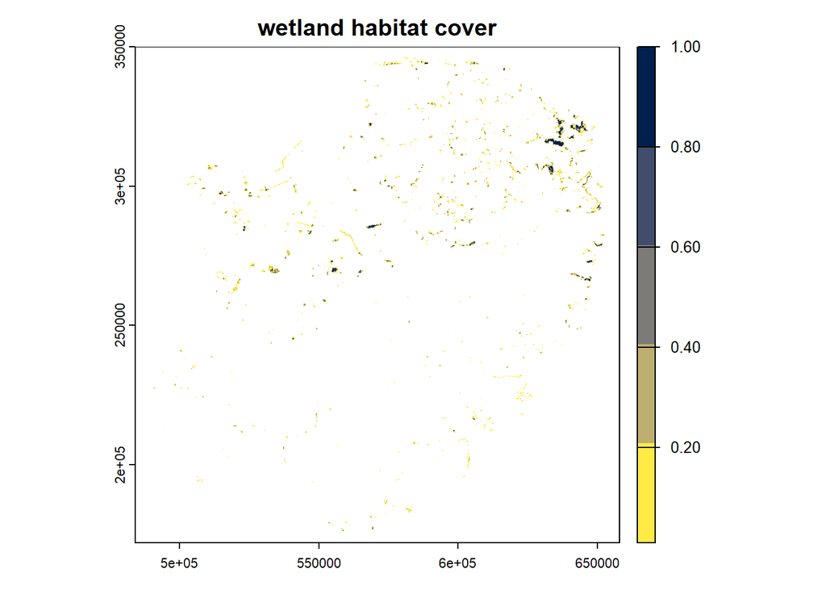

```r
library(terra)

eghab = rast("data/wetland_east.tif")

# Obtain Coordinate Reference System (crs) and extent (ext)
regextent = ext(eghab)
mycrs = crs(eghab)
myres = res(eghab)
unitcheck = linearUnits(eghab) # returns 1 if the unit is meters

# Plot the habitat with 5 cover categories
plot(eghab,col=cividis(5,direction=-1),main="wetland habitat cover")
```

### Sources and targets data

In this example we will assess the East-West connectivity of our landscape. So, we must add our Source-Target raster, which we define in our code as `direction`.

For the remaining plots/maps in this document, the code that produces them is hidden in the HTML version, but it can be seen by opening the rworkflow.Rmd file.

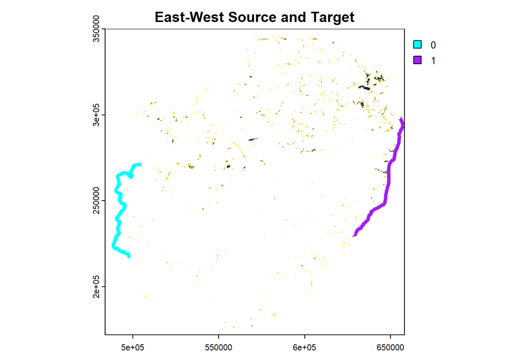

We can verify that our habitat and ST raster have the same spatial properties. Then name our ST raster accordingly. Defining `landname` and `dirnow` facilitates the reproducibility of the code for other landscapes or directions.

```r
landname = 'Wetland_East'
dirnow = 'W_E'

matches = TRUE
  if(!identical(myres,res(direction))){
    matches = FALSE
    warning(paste(
      "habitat has different resolution from st in direction",
      dirnow))
  }
  if(!identical(unitcheck,linearUnits(direction))){
    matches = FALSE
    warning(paste(
      "habitat has different distance unit from st in direction",
      dirnow))
  }
  if(matches){message(paste("st matches habitat in direction",dirnow))}
```

```
## st matches habitat in direction W_E
```

```r
#assign a new object where this source-target raster is labelled
#(as above, useful when running loops with multiple directions)
assign(paste0(landname,"_",dirnow), direction)
```

## Convert rasters to points

We now use the `makehabitatpoints`and `stargetpt` to convert our rasters into data frames. The habitat data frame (here named `Wetland_East_hab`) contains the columns required to run the Condatis analysis (i.e. x,y and cover), and obtain our output maps (xm and ym). Similarly, the `stnow` list contains, the data frames for the source and targets.

```r
# Name habitat according to variable 'landname' and convert raster to points
assign(paste0(landname,"_hab"),
       makehabitatpoints(eghab,inm=identical(unitcheck,1)))

# Get source and target points
stnow = stargetpt(get(paste0(landname,"_",dirnow)),
                  inm=identical(unitcheck,1))
```

## Run Condatis

### Set Condatis parameters

The user-defined inputs required for the Condatis function are:

- The habitat (`habpt`) and source-target (`sourcept`, `targetpt`) points obtained above.
- A dispersal distance in km (`disp`). Here we will use a 2 km dispersal distance.
- Cell side (`cellside`). We calculate the cell size in kilometers based on the resolution of the habitat raster, we named this `myres` above. If the raster units are not meter, the cellside will not be converted to km.
- Reproductive rate (`R`). This represent the average number of individuals produced per generation per km<sup>2</sup>. Here we set R to 1000.

Other parameters have default values, we will not modify them in this exercise. For details see the comments of the function `condatis_from_points`.

```r
Cdisp = 2

if(identical(unitcheck,1)){
Ccellside = myres[1]/1000 #resolution in m, cellside in km
}else{
  Ccellside= myres[1]# units left unchanged if they are not in m,
                     # as within raster to point conversions
}
```

### Run analysis

Now we can run the Condatis analysis. It can take some time, depending on the spec of your computer.

```r
result = condatis_from_points(
  habpt= get(paste0(landname,"_hab")), # habitat points
  sourcept=stnow$sourcept[,c("x","y")], # source points
  targetpt=stnow$targetpt[,c("x","y")], # target points
  R=1000,
  disp = Cdisp,
  cellside = Ccellside,
  metric ='ALL',
  filename =  NA,
  threshold = 0.95,
  minscore=1,
  maxlink = 1000,
  minlink = 1,
  maxdisp = Inf)
```

The `condatis_from_points` funtion will return **`results`**, a list with four elements:

- `overall` : a data frame with the summary of statistic
- `flow`: a data frame with the flow and progress values per patch (cell)
- `power`: a data frame with the power metrics per link (line), i.e. percentage of power (`powr`), and score (`score`), among other characterstics
- `bottleneck_ends`: a data frame with the start and end points of these links

We can check for unusual ‘voltages’ indicating computational errors.

```r
  jobok= result$overall$minprog > (0-10^-6)
  jobok= jobok & result$overall$maxprog < (1+10^-6)
  jobok
```

[output not shown]

If `jobok = TRUE`, we can continue to analyse our spatial results.

## Progress and Flow maps

We use the `progress` and `flow` columns from the `result$flow` data frame to rasterise the points and save these outputs as *.tif* raster files in an ‘outputs’ folder you will create.

```r
if(jobok){

  # rasterise 'progress' points
    progress = rast(result$flow[,c("xm","ym","progress")],
              type="xyz",
              crs=mycrs,
              digits=1,
              extent=regextent)

  assign(paste(landname, dirnow, "progress",sep="_"),
         progress)

  dir.create('outputs') #create an outputs folder

  # save raster
   writeRaster(progress,
               paste0('outputs/', paste(landname, dirnow, "progress",sep="_"),'.tif'),
               datatype = "FLT8S",
               overwrite = TRUE)

   # rasterise 'flow' points
   flow = rast(result$flow[,c("xm","ym","flow")],
              type="xyz",
              crs=mycrs,
              digits=1,
              extent=regextent)


   assign(paste(landname, dirnow, "flow",sep="_"),
          flow)
   # save raster
   writeRaster(flow,
               paste0('outputs/', paste(landname, dirnow, "flow",sep="_"),'.tif'),
               datatype = "FLT8S",
               overwrite = TRUE)

}
```

You can explore these rasters in your preferred GIS software, as well as plotting them in R, as below:

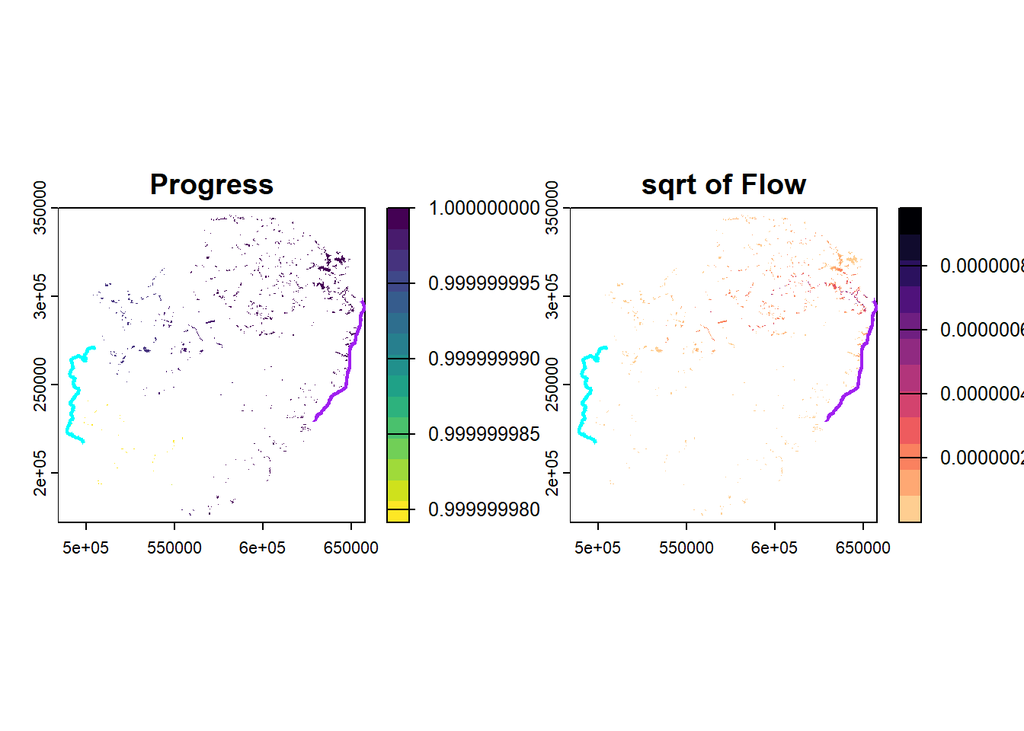

You might notice that where the landscape shows discontinuities/jumps in progress is where the most serious bottlenecks tend to be (compare the above plot with the search areas below). Also, it is clear that the flow is concentrated around the easiest route from the source to the target.

## Bottleneck lines

We use the `bottleneck_ends` output from the **`results`** list (*`result$bottleneck_ends`*) as the input for the `ends_to_lines` function . Then we save the results as a shapefile in the outputs folder you just created.

```r
  ends = result$bottleneck_ends

  ends$direction = dirnow # add the direction

  botlines = ends_to_lines(endstab=ends,
                           minscore=1,
                           crs=mycrs)

  assign(paste(landname, dirnow, "botlines",sep="_"),botlines)

  # save shapefile
  st_write(botlines,
           paste0('outputs/', paste(landname, dirnow, "botlines",sep="_"),'.shp'),
           append = FALSE)
```

## Search areas

Finaly, we can use the bottleneck links that we created above (`botlines`) to define ‘Search areas’ based on the bottleneck scores using the `zones_by_score_range` function.

In this example, we set the ‘major’ bottleneck areas defined by any links with a score between 5 and 50, and ‘severe’ bottleneck areas with a score greater than 50.

At the end of this section we combined the `areasMajor` and `areasSevere` outputs into a single dataset `areas`.

```r
majorscore = 5
severescore = 50

areasMajor = zones_by_score_range(
  botlines,
  score_range = c(majorscore,severescore),
  directioncol="direction")

areasSevere = zones_by_score_range(
  botlines,
  score_range = c(severescore,Inf),
  directioncol="direction")

if(!identical(areasMajor,NA)){   # The  zones_by_score_range function will return NA if                                  # there are no lines in the specified score range
  areasMajor$category = "Major"

  if(!identical(areasSevere, NA)){
    areasSevere$category = "Severe"
    areas = dplyr::bind_rows(areasMajor, areasSevere)

  } else{
    areas = areasMajor

  }
}

# Save shapefile of major and severe bottleneck areas
st_write(areas,
         paste0('outputs/',paste(landname, dirnow, "areas",sep="_"),'.shp'),
         append=FALSE)
```

Your shapefile will compile the areas categorised as ‘major’ or ‘severe’, the number of bottlenecks that are included in that areas and the sum of their scores.

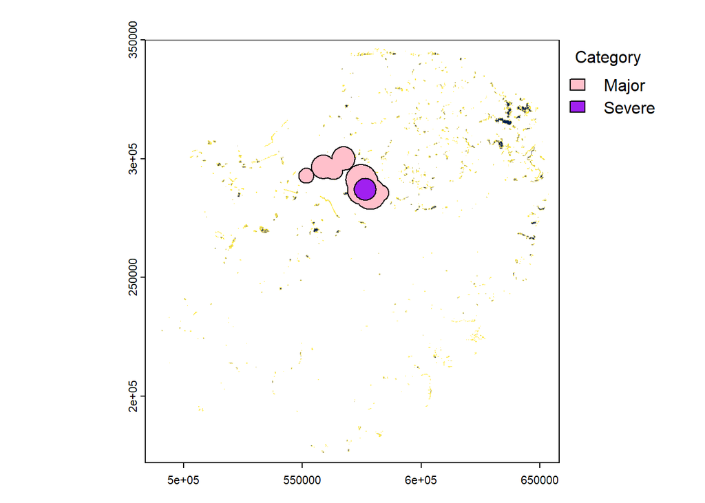

Now you can explore this shapefile ‘Wetland_East_W_E_areas.shp’ in your preferred GIS software. You could overlay the bottleneck lines and notice how the ‘areas’ make it simpler to focus on the most impactful bottlenecks.

## Other directions - optional extra

You can change the input data in the Sources and targets data section, for example:

```r
direction = rast("data/east_NW_SE.tif")
```

Remember to change the name of your `dirnow` variable accordingly.

```r
landname = 'Wetland_East'
dirnow = 'NW_SE'
```

These are the directions available in this exercise:

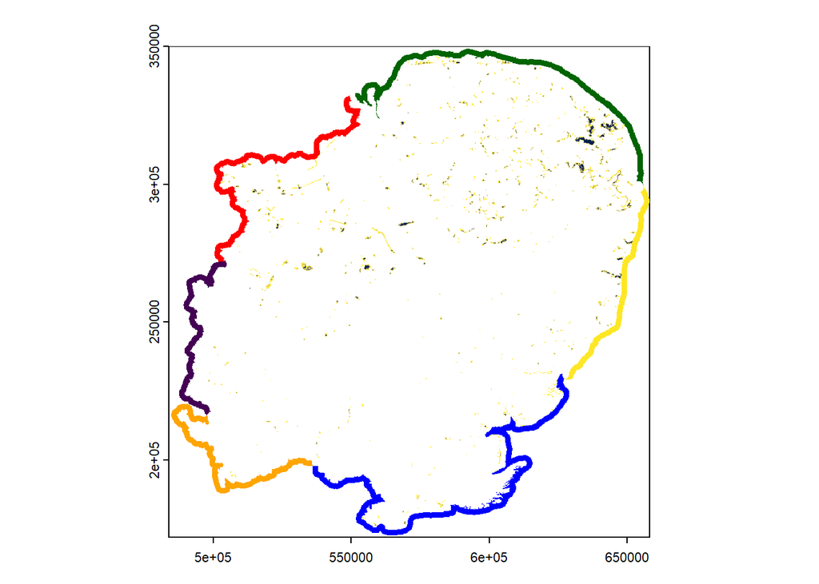

```r
library(terra)

eghab = rast("data/wetland_east.tif")
direction = rast("data/east_W_E.tif")
direction2 = rast("data/east_NW_SE.tif")
direction3 = rast("data/east_SW_E.tif")

plot(eghab,col=cividis(5,direction=-1), legend = FALSE)
plot(direction, add=TRUE, legend = FALSE)
plot(direction2, add=TRUE, col =c('red','blue'), legend = FALSE)
plot(direction3, add=TRUE, col =c('orange','darkgreen'), legend = FALSE)
```

We have not provided you with code to compile these three directions into a loop and run them all. You would have to Convert rasters to points for these new directions and Run Condatis analyses with them. We’d only recommend doing this if you are practised in using R for loops.

## Multidirectional search areas

It is possible to combine the bottlenecks of multiple directions by appending the shapefiles of the Bottleneck lines (named *botlines*) for the multiple directions and apply the `zones_by_score_range` function (as described in Search areas). We have not provided code for this, but we have saved the end result in the QGIS_project folder. Here is a way to plot the ‘search areas’ considering the three directions of movement for this wetland landscape.

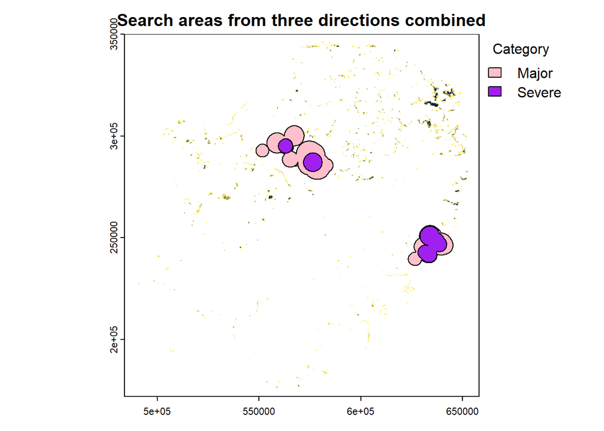